# Bellabeat Marketing Project: A Case Study

Mario Severo

07-02-2022

This R Markdown notebook documents the steps undertaken for the data analysis case study entitled, **“How Can a Wellness Technology Company Play It Smart?”**. It serves as a *capstone* for the **Google Data Analytics Course**. This notebook explains the the data analytic processes performed by the author to arrive to the key insights and proposal for a business task from a high-tech company.

## 1. The client and stakeholders

The client, [**Bellabeat**](https://bellabeat.com/about/), is a a high-tech manufacturing company specializing in health-focused products for women. They develop wearable smart devices and accompanying products that track biometric and lifestyle data to aid women improve their overall health.

[figure not shown]

The stakeholders for this project includes:

- Urška Sršen: Bellabeat’s cofounder and Chief Creative Oﬃcer
- Sando Mur: Mathematician and Bellabeat’s cofounder; key member of the Bellabeat executive team
- Bellabeat marketing analytics team: A team of data analysts responsible for collecting, analyzing, and reporting data that helps guide Bellabeat’s marketing strategy.

## 2. The business task

The business task is to identify trends from an open-access data on smart device usage that can be applied for a marketing strategy plan to Bellabeat customers. Specifically, the following questions are to be answered:

1. What are some trends in smart device usage?
2. How could these trends apply to Bellabeat customers?
3. How could these trends help influence Bellabeat marketing strategy?

## 3. The dataset

The dataset, [**FitBit Fitness Tracker Data**](https://www.kaggle.com/arashnic/fitbit), is an [**open-access**](https://zenodo.org/record/53894#.YgFyodXMLDe) **personal tracker data** collected from Fitbit users (*n* = 33) who participated in a survey on Amazon Mechanical Turk from 03/12/2016 till 05/12/2016. It contains time series data on the following users’ information, such as number of steps, distance traveled, activity calories, sleeping pattern, heart rate, etc.

Some **data limitations** to consider:

- Age, gender, health-status, and other relevant sociodemographic information of participants were not accounted for (possibly a heterogeneous sample)
- Sample size (*n* = 33) was not consistent across all the measures of the dataset
- Some data inconsistencies (due to differences in Fitbit tracker types and individual tracking behaviors/preferences)
- Data is not recently collected nor updated
- Data is external (not provided by the client)

## 4. Data analysis steps

This section details the data analysis steps performed on the Fitbit dataset. For the purposes of this project, I mainly focused on two pieces of information with relatively ample sample size and data points. Specifically, the explorarory data analysis (EDA) performed here centered on the **1) physical activity output record** and the **2) sleep log**.

### 4.1 Setting-up

Begin with loading previously installed packages that will be used for different reasons: 1)`pacman` for loading packages at once; 2) `tidyverse`, `skimr`, `janitor`, and `lubridate` for data cleaning, organization, and transformation; 3) `ggplot2` and `cowplot` for data visualization.

```r
library(pacman)
pacman::p_load(tidyverse, ggplot2, skimr, janitor, lubridate, cowplot)
```

Next, loading up the Fitbit Tracker Dataset. It is composed of several csv files logging the following users’ information.

The *physical activity output log* contains the 1) *number of daily step* recorded by the Fitbit users, 2) the *walking distance* they covered, the *calories* they burned, and the *duration of the activities of varying intensities* that they performed within the recording period. This particular recording has two main data frames, one for **daily step recordings**, and another for **hourly step recordings**.

The *sleep log* contains the daily sleep duration (in minutes), the time spent in bed, and the number of sleep. For the sleep analysis, I mainly focused on the first two information.

### 4.2 Data cleaning and transformation

#### 4.2.1 Physical activity output log

##### 4.2.1.1 Daily activity log

Data summary

| Name | daily_steps |
| --- | --- |
| Number of rows | 940 |
| Number of columns | 15 |
| _______________________ |  |
| Column type frequency: |  |
| character | 1 |
| numeric | 14 |
| ________________________ |  |
| Group variables | None |

**Variable type: character**

| skim_variable | n_missing | complete_rate | min | max | empty | n_unique | whitespace |
| --- | --- | --- | --- | --- | --- | --- | --- |
| ActivityDate | 0 | 1 | 8 | 9 | 0 | 31 | 0 |

**Variable type: numeric**

| skim_variable | n_missing | complete_rate | mean | sd | p0 | p25 | p50 | p75 | p100 |
| --- | --- | --- | --- | --- | --- | --- | --- | --- | --- |
| Id | 0 | 1 | 4.855407e+09 | 2.424805e+09 | 1503960366 | 2.320127e+09 | 4.445115e+09 | 6.962181e+09 | 8.877689e+09 |
| TotalSteps | 0 | 1 | 7.637910e+03 | 5.087150e+03 | 0 | 3.789750e+03 | 7.405500e+03 | 1.072700e+04 | 3.601900e+04 |
| TotalDistance | 0 | 1 | 5.490000e+00 | 3.920000e+00 | 0 | 2.620000e+00 | 5.240000e+00 | 7.710000e+00 | 2.803000e+01 |
| TrackerDistance | 0 | 1 | 5.480000e+00 | 3.910000e+00 | 0 | 2.620000e+00 | 5.240000e+00 | 7.710000e+00 | 2.803000e+01 |
| LoggedActivitiesDistance | 0 | 1 | 1.100000e-01 | 6.200000e-01 | 0 | 0.000000e+00 | 0.000000e+00 | 0.000000e+00 | 4.940000e+00 |
| VeryActiveDistance | 0 | 1 | 1.500000e+00 | 2.660000e+00 | 0 | 0.000000e+00 | 2.100000e-01 | 2.050000e+00 | 2.192000e+01 |
| ModeratelyActiveDistance | 0 | 1 | 5.700000e-01 | 8.800000e-01 | 0 | 0.000000e+00 | 2.400000e-01 | 8.000000e-01 | 6.480000e+00 |
| LightActiveDistance | 0 | 1 | 3.340000e+00 | 2.040000e+00 | 0 | 1.950000e+00 | 3.360000e+00 | 4.780000e+00 | 1.071000e+01 |
| SedentaryActiveDistance | 0 | 1 | 0.000000e+00 | 1.000000e-02 | 0 | 0.000000e+00 | 0.000000e+00 | 0.000000e+00 | 1.100000e-01 |
| VeryActiveMinutes | 0 | 1 | 2.116000e+01 | 3.284000e+01 | 0 | 0.000000e+00 | 4.000000e+00 | 3.200000e+01 | 2.100000e+02 |
| FairlyActiveMinutes | 0 | 1 | 1.356000e+01 | 1.999000e+01 | 0 | 0.000000e+00 | 6.000000e+00 | 1.900000e+01 | 1.430000e+02 |
| LightlyActiveMinutes | 0 | 1 | 1.928100e+02 | 1.091700e+02 | 0 | 1.270000e+02 | 1.990000e+02 | 2.640000e+02 | 5.180000e+02 |
| SedentaryMinutes | 0 | 1 | 9.912100e+02 | 3.012700e+02 | 0 | 7.297500e+02 | 1.057500e+03 | 1.229500e+03 | 1.440000e+03 |
| Calories | 0 | 1 | 2.303610e+03 | 7.181700e+02 | 0 | 1.828500e+03 | 2.134000e+03 | 2.793250e+03 | 4.900000e+03 |

```
##                       Id             ActivityDate               TotalSteps
##                    FALSE                    FALSE                    FALSE
##            TotalDistance          TrackerDistance LoggedActivitiesDistance
##                    FALSE                    FALSE                    FALSE
##       VeryActiveDistance ModeratelyActiveDistance      LightActiveDistance
##                    FALSE                    FALSE                    FALSE
##  SedentaryActiveDistance        VeryActiveMinutes      FairlyActiveMinutes
##                    FALSE                    FALSE                    FALSE
##     LightlyActiveMinutes         SedentaryMinutes                 Calories
##                    FALSE                    FALSE                    FALSE
```

##### 4.2.1.2 Hourly steps

Data summary

| Name | hourly_steps |
| --- | --- |
| Number of rows | 22099 |
| Number of columns | 6 |
| _______________________ |  |
| Column type frequency: |  |
| character | 1 |
| numeric | 5 |
| ________________________ |  |
| Group variables | None |

**Variable type: character**

| skim_variable | n_missing | complete_rate | min | max | empty | n_unique | whitespace |
| --- | --- | --- | --- | --- | --- | --- | --- |
| ActivityHour | 0 | 1 | 19 | 21 | 0 | 736 | 0 |

**Variable type: numeric**

| skim_variable | n_missing | complete_rate | mean | sd | p0 | p25 | p50 | p75 | p100 |
| --- | --- | --- | --- | --- | --- | --- | --- | --- | --- |
| Id | 0 | 1 | 4.848235e+09 | 2.4225e+09 | 1503960366 | 2320127002 | 4.445115e+09 | 6.962181e+09 | 8877689391 |
| TotalIntensity | 0 | 1 | 1.204000e+01 | 2.1130e+01 | 0 | 0 | 3.000000e+00 | 1.600000e+01 | 180 |
| AverageIntensity | 0 | 1 | 2.000000e-01 | 3.5000e-01 | 0 | 0 | 5.000000e-02 | 2.700000e-01 | 3 |
| Calories | 0 | 1 | 9.739000e+01 | 6.0700e+01 | 42 | 63 | 8.300000e+01 | 1.080000e+02 | 948 |
| StepTotal | 0 | 1 | 3.201700e+02 | 6.9038e+02 | 0 | 0 | 4.000000e+01 | 3.570000e+02 | 10554 |

```
##               Id     ActivityHour   TotalIntensity AverageIntensity
##            FALSE            FALSE            FALSE            FALSE
##         Calories        StepTotal
##            FALSE            FALSE
```

#### 4.2.2 Sleep log

Data summary

| Name | sleep |
| --- | --- |
| Number of rows | 413 |
| Number of columns | 5 |
| _______________________ |  |
| Column type frequency: |  |
| character | 1 |
| numeric | 4 |
| ________________________ |  |
| Group variables | None |

**Variable type: character**

| skim_variable | n_missing | complete_rate | min | max | empty | n_unique | whitespace |
| --- | --- | --- | --- | --- | --- | --- | --- |
| SleepDay | 0 | 1 | 20 | 21 | 0 | 31 | 0 |

**Variable type: numeric**

| skim_variable | n_missing | complete_rate | mean | sd | p0 | p25 | p50 | p75 | p100 |
| --- | --- | --- | --- | --- | --- | --- | --- | --- | --- |
| Id | 0 | 1 | 5.000979e+09 | 2.06036e+09 | 1503960366 | 3977333714 | 4702921684 | 6962181067 | 8792009665 |
| TotalSleepRecords | 0 | 1 | 1.120000e+00 | 3.50000e-01 | 1 | 1 | 1 | 1 | 3 |
| TotalMinutesAsleep | 0 | 1 | 4.194700e+02 | 1.18340e+02 | 58 | 361 | 433 | 490 | 796 |
| TotalTimeInBed | 0 | 1 | 4.586400e+02 | 1.27100e+02 | 61 | 403 | 463 | 526 | 961 |

```
##                 Id           SleepDay  TotalSleepRecords TotalMinutesAsleep
##              FALSE              FALSE              FALSE              FALSE
##     TotalTimeInBed
##              FALSE
```

### 4.3 Data analysis

#### 4.3.1 Daily physical activity output analysis

##### 4.3.1.1 Average daily physical output in a week

When exploring the average daily physical output of Fitbit users (*n* = 33), as measured by the daily steps they make (see plot A), the distance they cover (see plot B), and the calories they burn (see plot C) when walking, they seem to show consistency in their daily outputs. As the figures below show, **changes in the daily step count, the walking distance, and the burned calories do not vary drastically everyday,** which seem to suggest a regularity and structure in their everyday activities.

Earlier physical activity recommendations for adults (18-64 yrs old) by the World Health Organization (2008) have used daily steps as one of the indices (i.e., pedometer index) for a healthy lifestyle promotion. Based on which, the **Fitbit users would qualify as a ‘somewhat active’ group**, with daily steps falling within 7500 - 9999 (see plot A). While this is below from the recommended 10,000 steps per day (WHO, 2008), the Fitbit users are still far from having a sedentary lifestyle, which is below 5,000 steps.

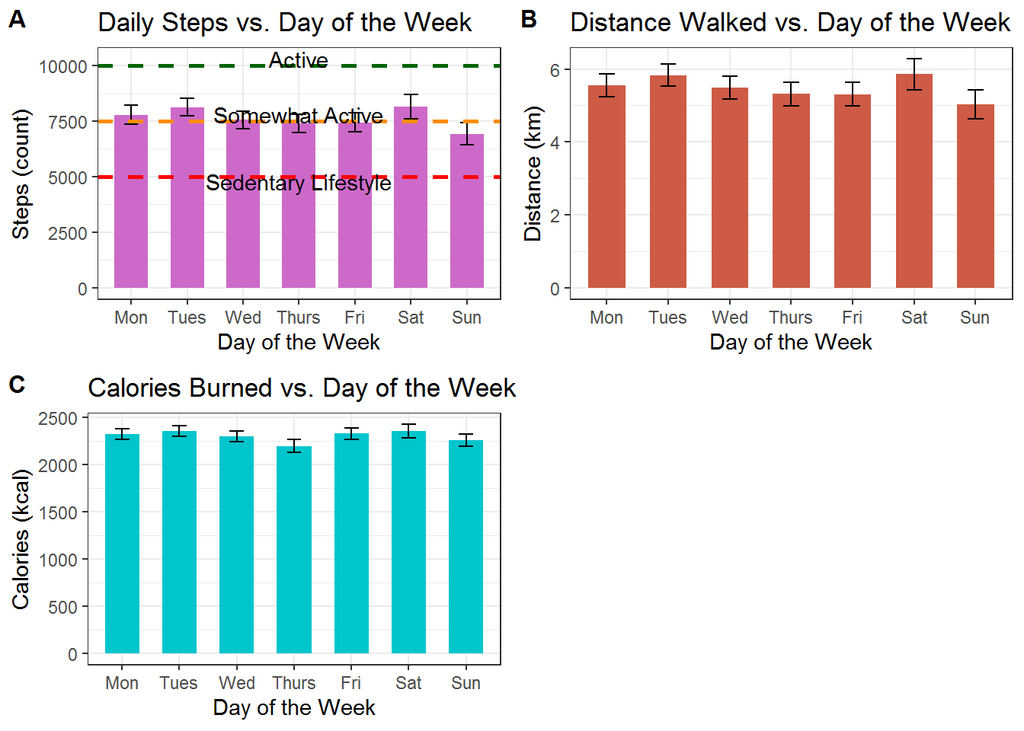

##### 4.3.1.2 Relationship between daily activity and calories burned

When exploring the relationship between daily steps of the Fitbit users and calories they burned, the plot shows a positive relationship between the two variables: **the more steps they make, the more calories they burn**.

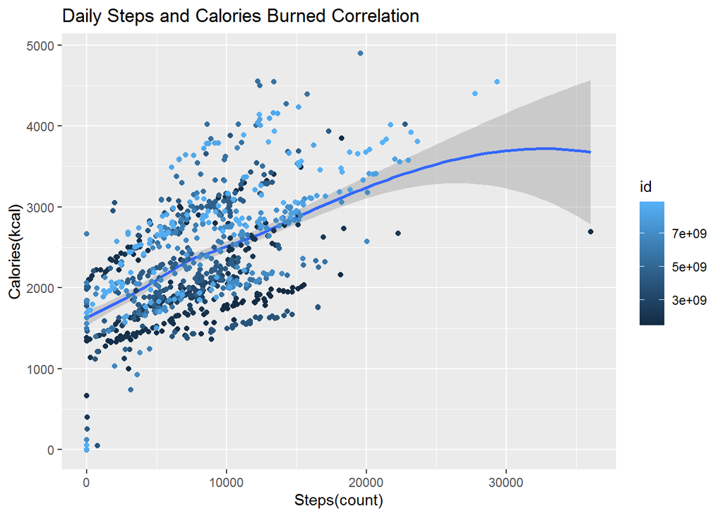

Similarly, when exploring the relationship between total distance they walked and the calories they burned, the plot shows a positive relationship between the two variables: **the more distance they cover walking, the more calories they burn**.

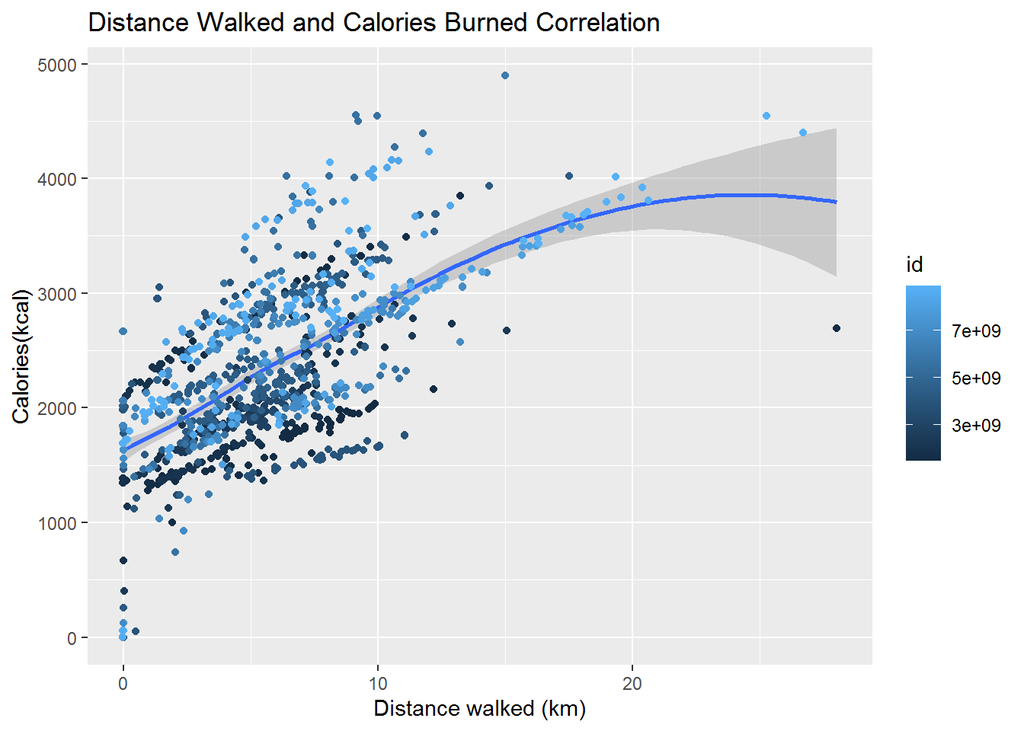

##### 4.3.1.3 Average time spent doing daily activities of varying intensity

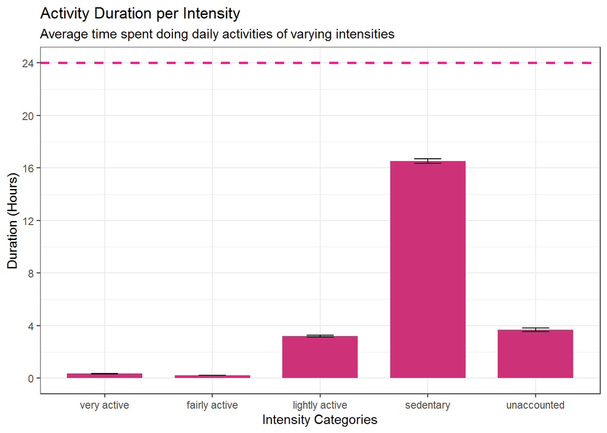

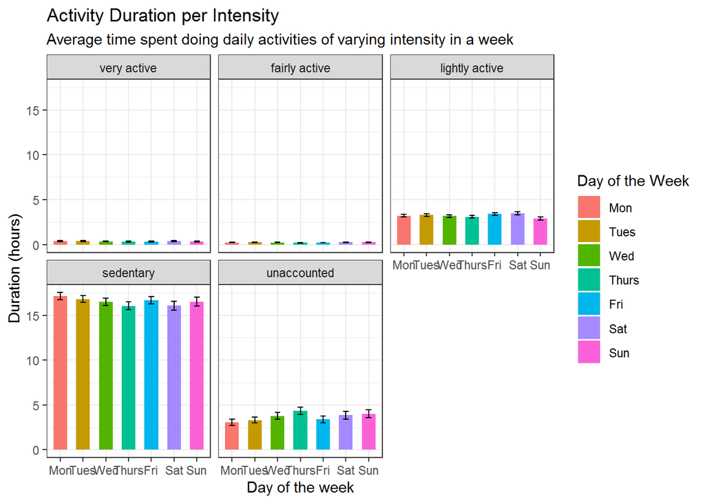

##### 4.3.1.4 Average time spent doing very active task vs. Days of the week

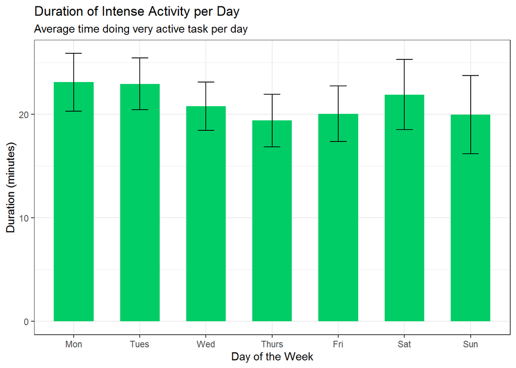

#### 4.3.2 Hourly physical activity output analysis

##### 4.3.2.1 Hourly physical activity output analysis

When exploring the physical activity output of Fitbit users (*n* = 33) recorded hourly, **it seems that the daily step taken (see plot A) and the calories burned (see plot B) tend to ramp up around the time users start their day**, i.e., 7:00. Both measures also tend to peak towards the evening, after 17:00, which possibly reflect after-work movements/activities (such as commuting or shopping).

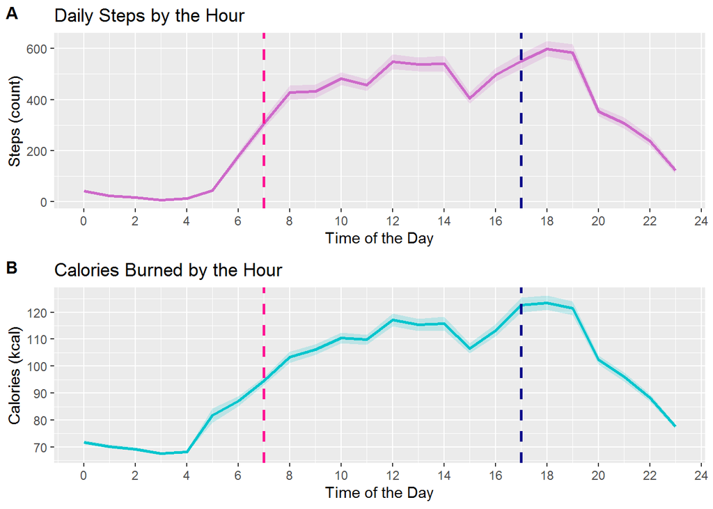

##### 4.3.2.2 Hourly physical activity output analysis per week type

When comparing the hourly physical activity output on weekends vs. weekdays, both **the increase in the daily steps (see plot A) and calories burned (see plot B) tend to be delayed at a later time on weekends than weekdays**. This is to be expected when we assume that Fitbit users follow a more rigid working schedule on the weekdays and take a more relaxed approach to start their day on the weekends. **It is also interesting to note that both daily steps and calories burned tend to be higher during the weekends than the weekdays from 11:00 - 16:00**. This could be due to the differences in the activities that Fitbit users engaged in opposite the week types. It could be assumed that users perform more activities related to health (such as exercise or walking) or leisure (such as shopping or strolling) during the weekends, while they work during the weekdays. Moreover, there is a shift in the increase of the daily steps and the calories burned at the later time of the day between the week types. After 16:00, both measures tend to be higher during the weekdays than the weekends. This could be attributed to the users’ after-work movements/activities on weekdays.

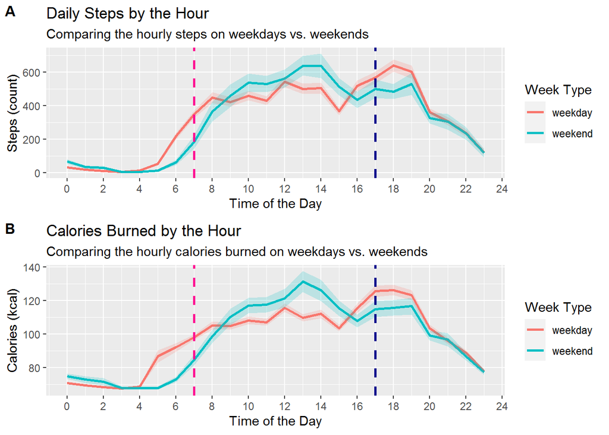

#### 4.3.3 Sleep analysis

##### 4.3.3.1 Daily sleep intake

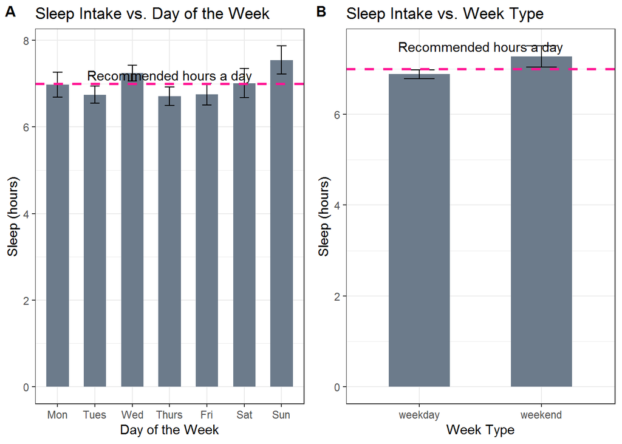

##### 4.3.3.1 Time spent in bed analysis

When exploring for the time spent in bed, which Fitbit defines as the time spent asleep, restless, and awake during a defined sleep record period, users tend to show slight variations on average bed time across the different days of the week (see plot A). Generally, **Fitbit users tend to stay in bed more than 7 hours**. Moreover, **they tend to spend more time in bed on average on the weekends than the weekdays** (see plot B).

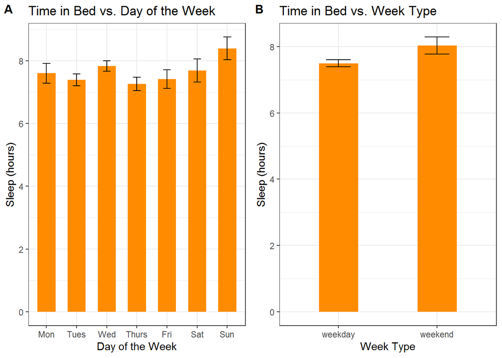

## 5. Discussion

### 5.1 Key trends on smart device usage

**1) Physical activity outputs and sleep records show small variations per day**  
One noticeable trend from the of Fitbit users was the little variations in their outputs when averaged per day. From the measures of their total steps, the distance they walk, the calories they burn, the duration of physical activities to their sleep intake - their outputs tend to show some consistency every day. This could translate into users having some regularity and structure in their daily activities that their smart device can record, monitor, and analyze.

## 6. References

- Furberg, R., Brinton, J., Keating, M., & Ortiz, A. (2016). Crowd-sourced Fitbit datasets 03.12.2016-05.12.2016 [Data set]. Zenodo. https://doi.org/10.5281/zenodo.53894
- Kaftan, O.J., & Freund, A.M. (2018). The way is the goal: The role of goal focus for successful goal pursuit and subjective well-being. In E. Diener, S. Oishi, & L. Tay (Eds.), Handbook of well-being. Salt Lake City, UT: DEF Publishers. DOI:nobascholar.com
- R Core Team (2021). R: A language and environment for statistical computing. R Foundation for Statistical Computing, Vienna, Austria. URL https://www.R-project.org/.
- Soni, Y. (2018). How I analyzed the data from my Fitbit to improve my overall health. Retrieved on Feb. 027, 2022 from https://www.freecodecamp.org/news/how-i-analyzed-the-data-from-my-fitbit-to-improve-my-overall-health-a2e36426d8f9/.
- Torre, I., Sanchez, O. R., Koceva, F., & Adorni, G. (2018). Supporting users to take informed decisions on privacy settings of personal devices. *Personal and Ubiquitous Computing, 22*(2), 345–364.https://doi.org/10.1007/s00779-017-1068-3.
- Watson N.F., Badr M.S., Belenky G., Bliwise, D.L., Buxton, O.M., Buysse, D., Dinges, D.F., Gangwisch, J., Grandner, M.A., Kushida, C., Malhotara, R., Martin, J.L., Patel, S., Quan, S.F., & Tasali E. (2015). Recommended amount of sleep for a healthy adult: a joint consensus statement of the American Academy of Sleep Medicine and Sleep Research Society. *Sleep, 38*(6):843–844.
- World Health Organization. Regional Office for the Western Pacific. (2008). Pacific physical activity guidelines for adults : framework for accelerating the communication of physical activity guidelines. WHO Regional Office for the Western Pacific. https://apps.who.int/iris/handle/10665/207007